# Ring analysis

Lorenzo Trubian

8/12/2021

## Section 1

### Double ring

Aside from the correctness and the efficiency of the program, we can note two main facts regard to the collected data: - first of all the relation between the execution time and the number of processor is linear; - and in the second place there are only two clearly different slopes.

We can explain the first note remembering that the only difference between execution with two number of processors regard how many iteration are required for each processors to receive its original message. Increasing the *number of process* by one means increasing the *number of process through which the message has to pass* by one, and therefore means increasing the *number of iteration* to complete the loop by one.

The second observation is trivially explainable if we note that the main gap in the considered communication is the latency of the network: if the nodes are two, three or four the latency is always given by the Infiniband network, therefore the slopes of time execution of these three measurements are perfectly equal. We observe that in one-node scenario the latency is lower and so is the slope.

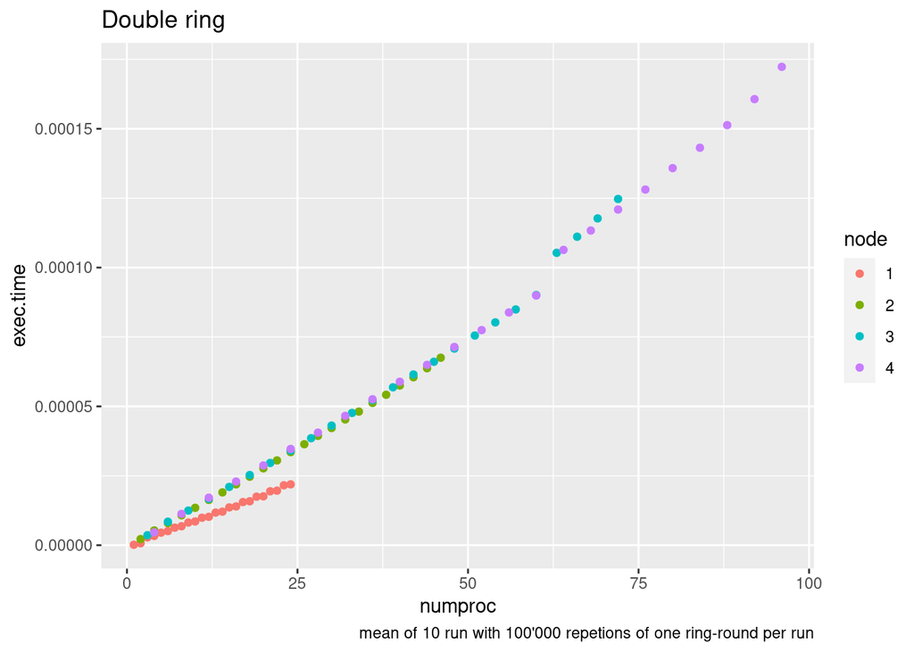

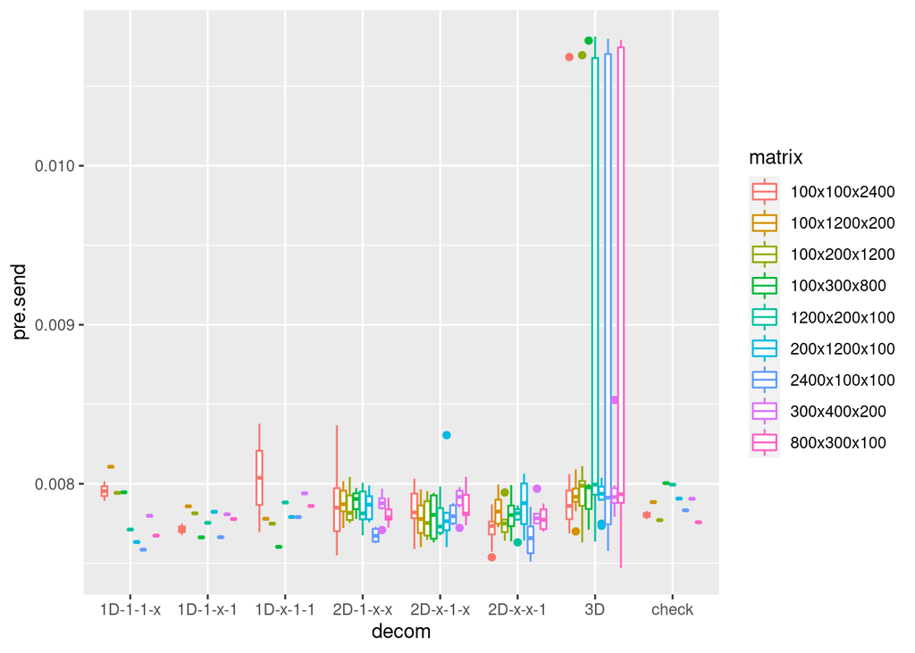

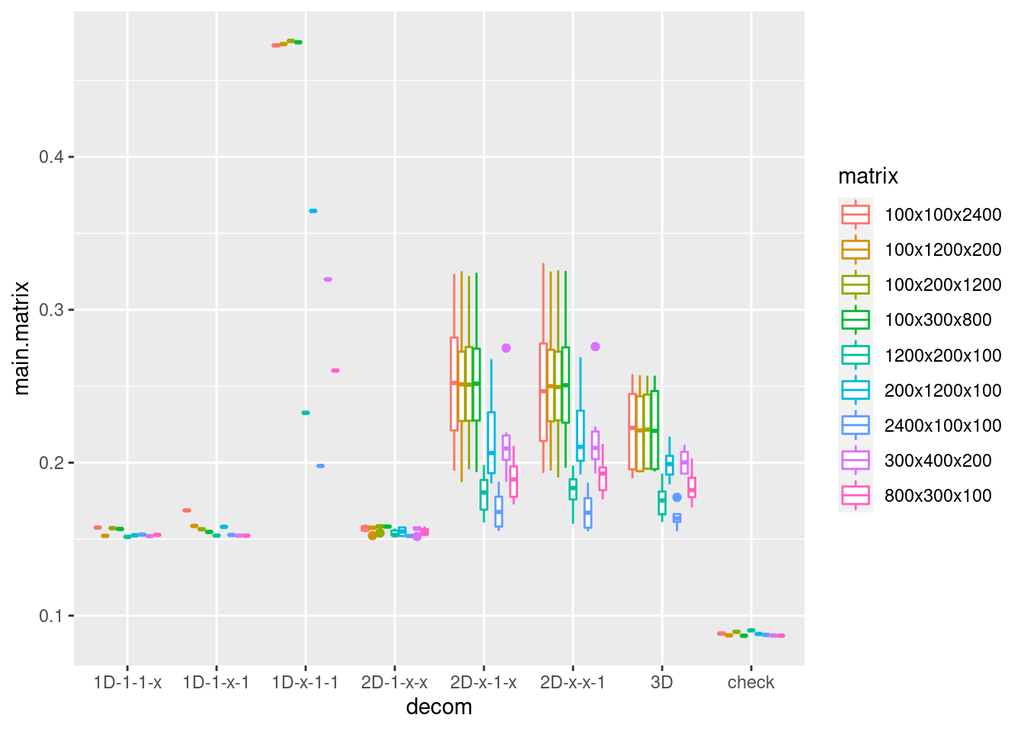

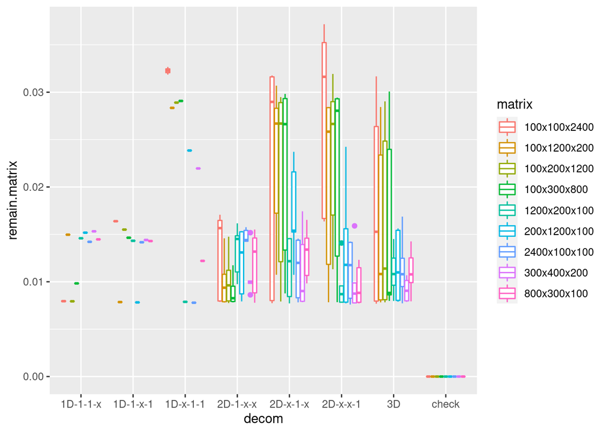

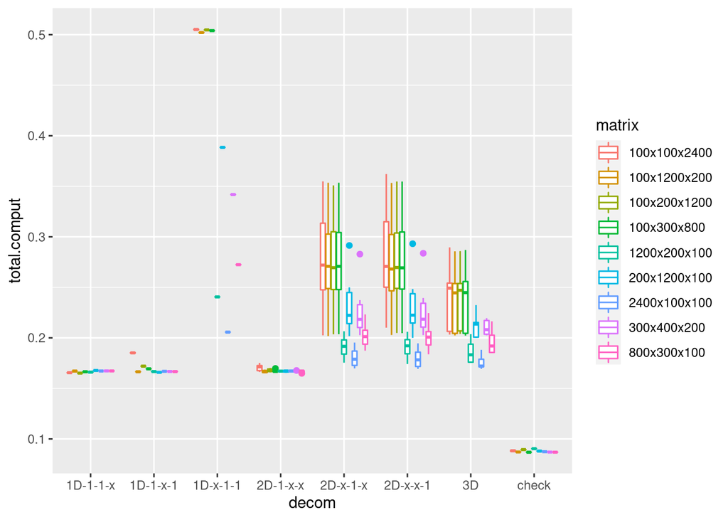

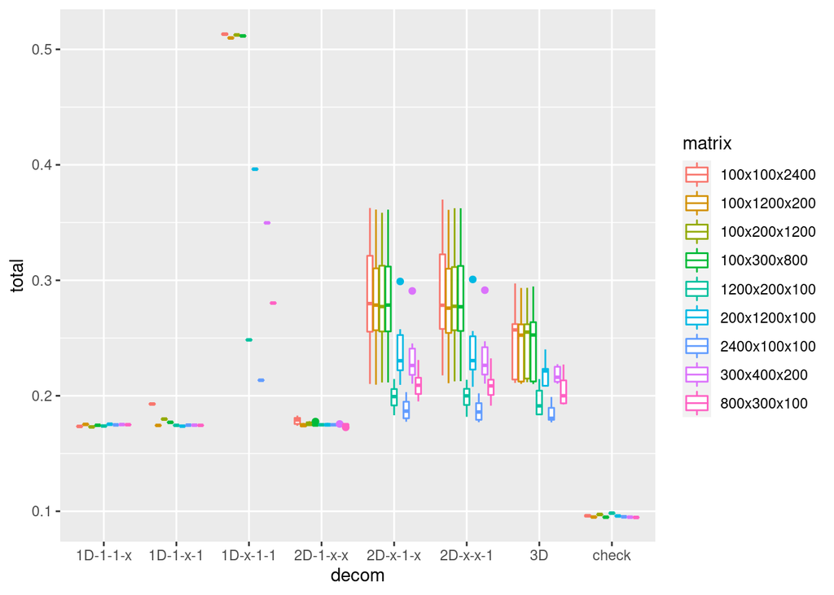

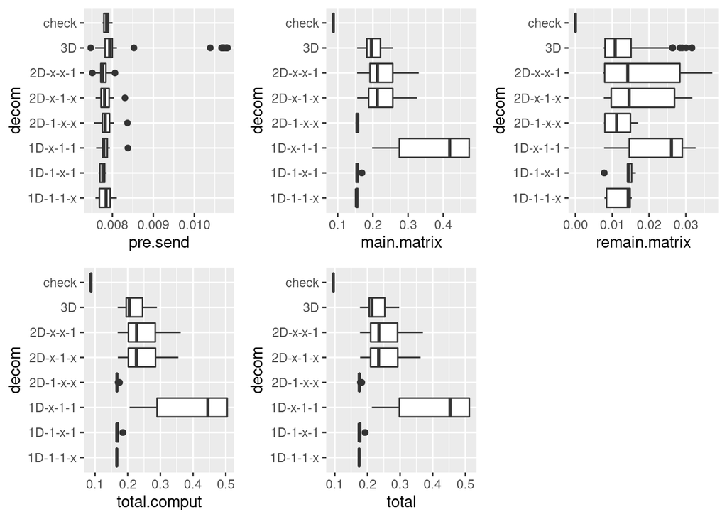

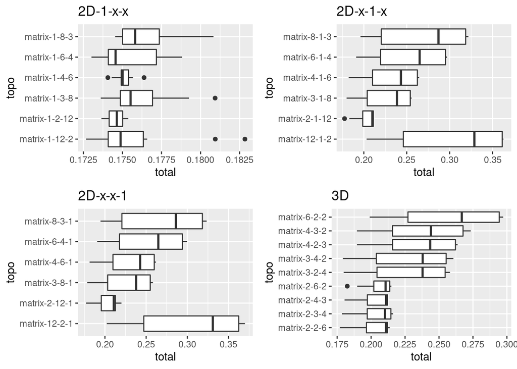

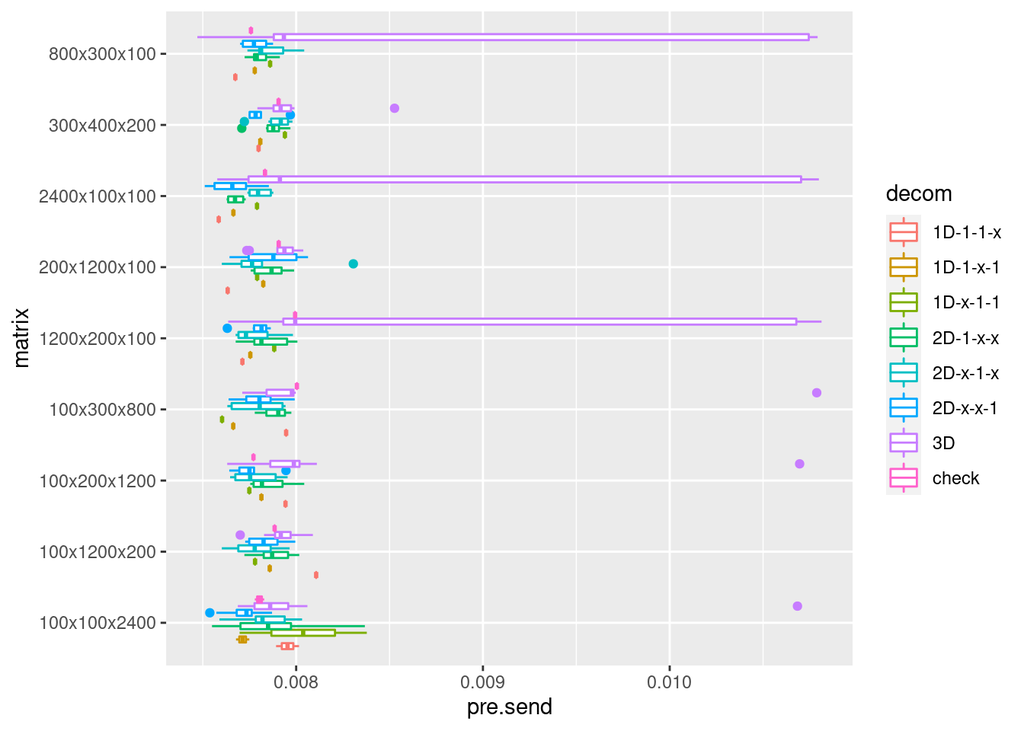

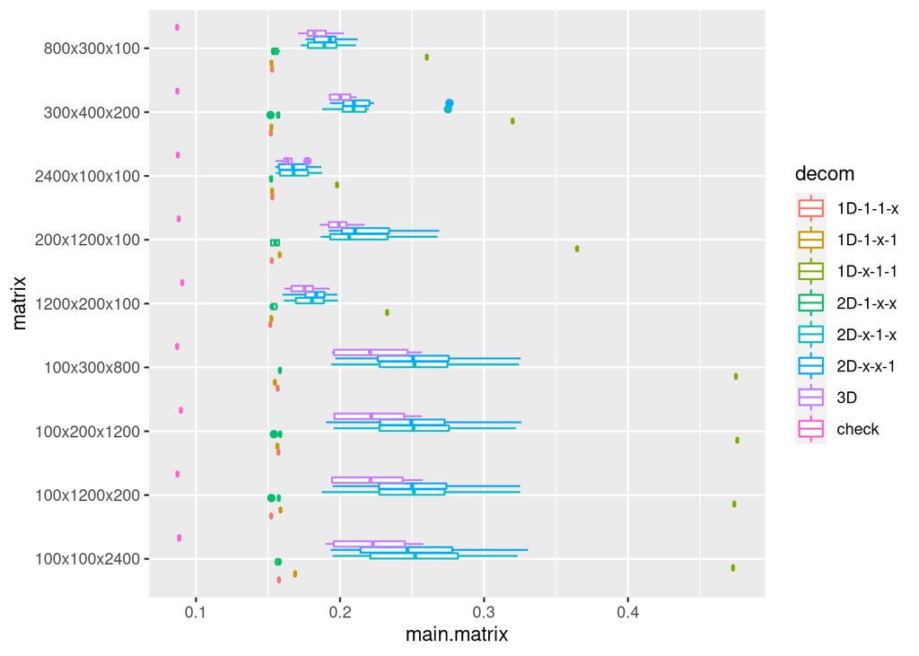

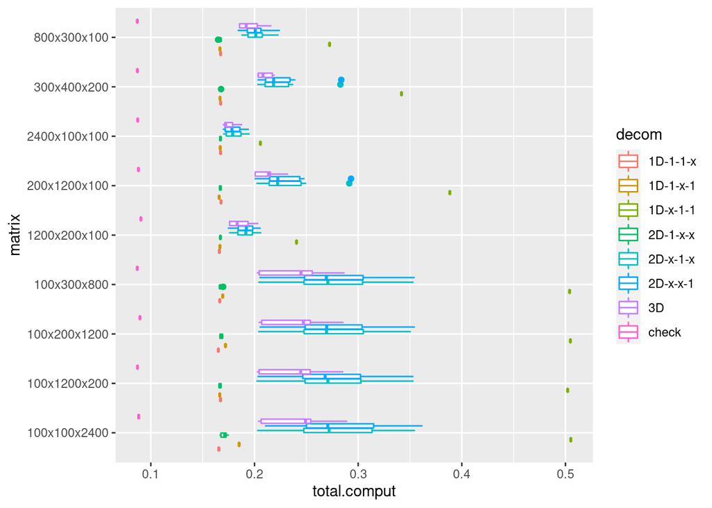

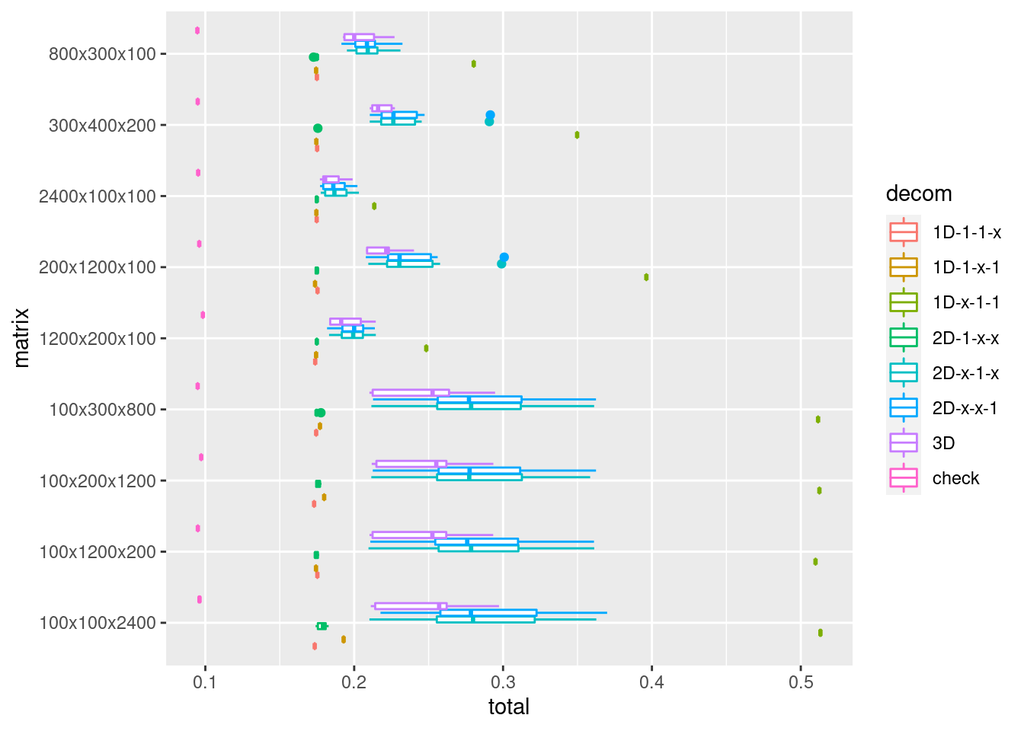

# PingPong

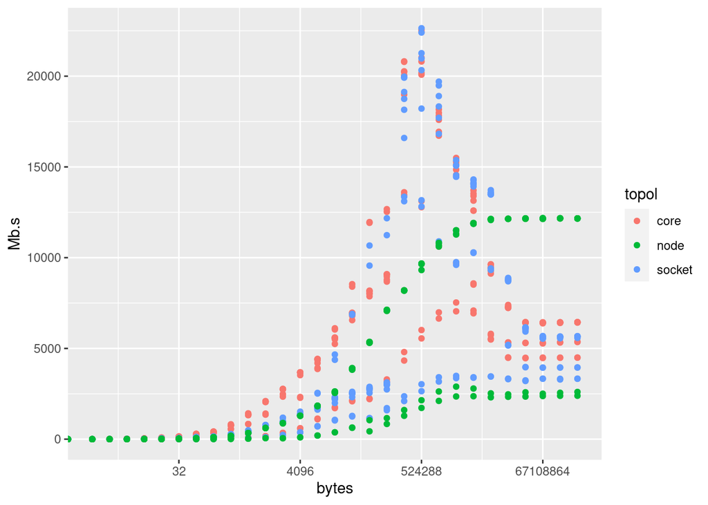

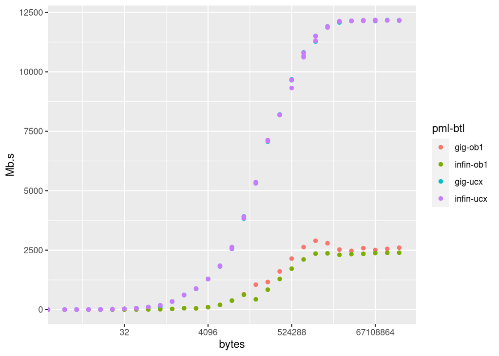

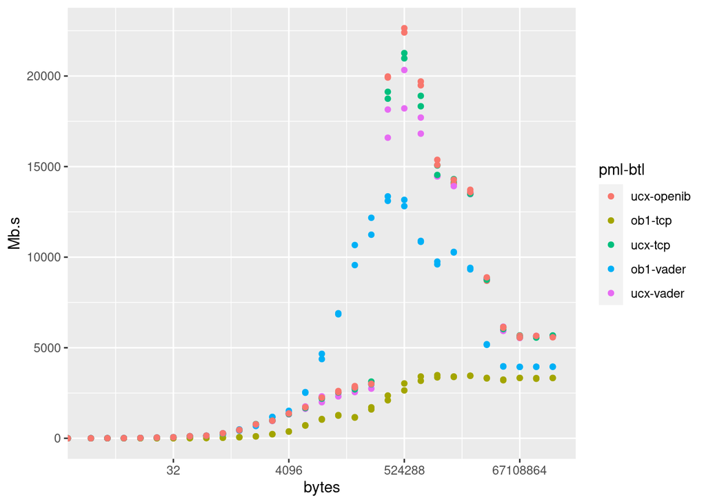

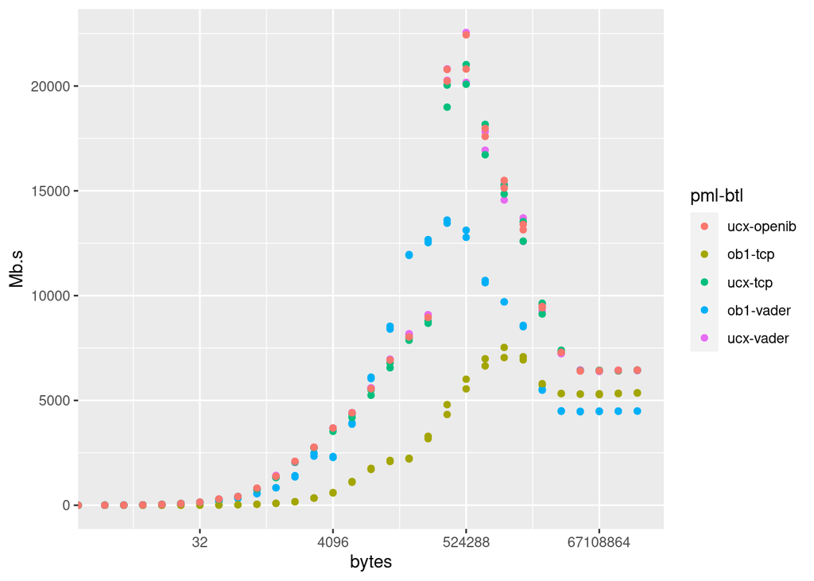

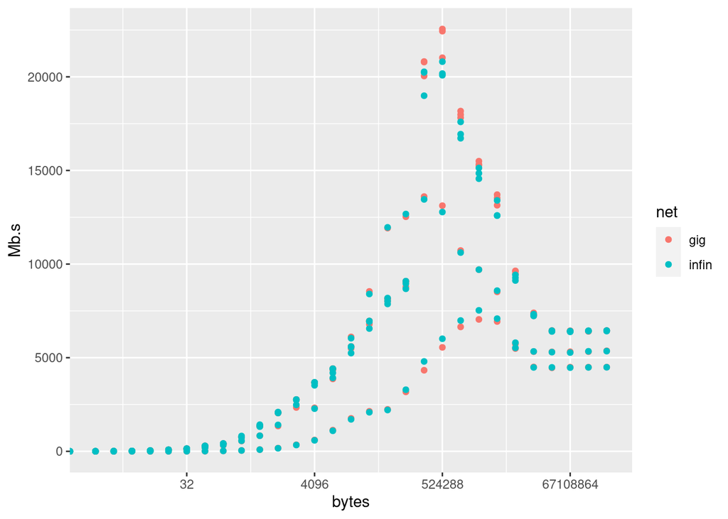

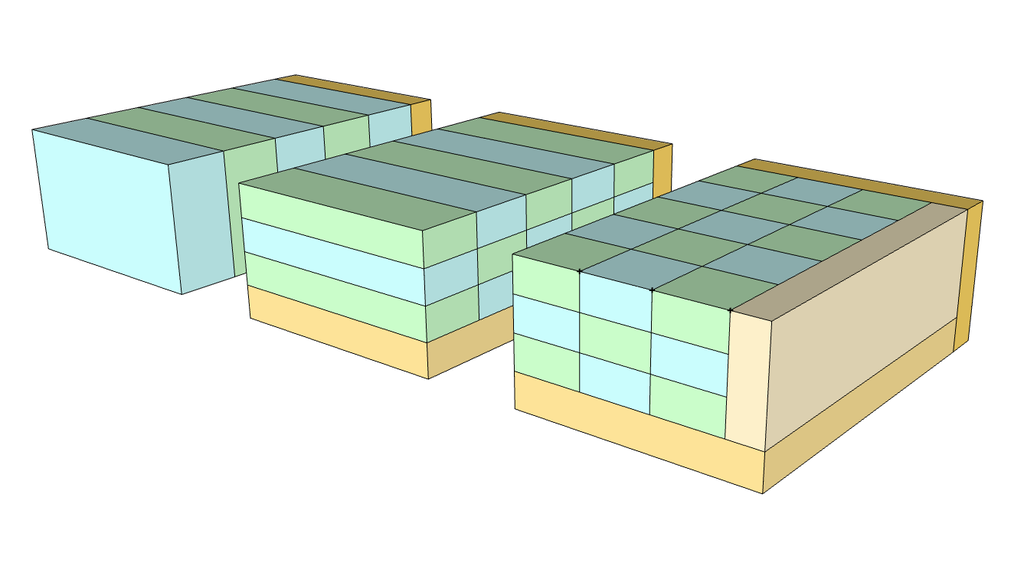

```
##      N grid.type   grid k node.tyep       topo   C(L,N)      Tc(L,N)    P(L,N)
## 1    4     x-1-1  4-1-1 1      thin       core 2.746582 0.0004233367  448.0393
## 2    4     1-x-1  1-4-1 1      thin       core 2.746582 0.0004233367  448.0393
## 3    4     1-1-x  1-1-4 1      thin       core 2.746582 0.0004233367  448.0393
## 4    4     x-x-1  2-2-1 2      thin       core 5.493164 0.0008466735  447.9361
## 5    4     1-x-x  1-2-2 2      thin       core 5.493164 0.0008466735  447.9361
## 6    4     x-1-x  2-1-2 2      thin       core 5.493164 0.0008466735  447.9361
## 7    8     x-1-1  8-1-1 1      thin       core 2.746582 0.0004233367  896.0785
## 8    8     x-x-1  4-2-1 2      thin       core 5.493164 0.0008466735  895.8723
## 9    8     x-1-x  4-1-2 2      thin       core 5.493164 0.0008466735  895.8723
## 10   8     x-x-1  2-4-1 2      thin       core 5.493164 0.0008466735  895.8723
## 11   8     1-x-1  1-8-1 1      thin       core 2.746582 0.0004233367  896.0785
## 12   8     1-x-x  1-4-2 2      thin       core 5.493164 0.0008466735  895.8723
## 13   8     x-1-x  2-1-4 2      thin       core 5.493164 0.0008466735  895.8723
## 14   8     1-x-x  1-2-4 2      thin       core 5.493164 0.0008466735  895.8723
```

[output cut: 681 more lines]

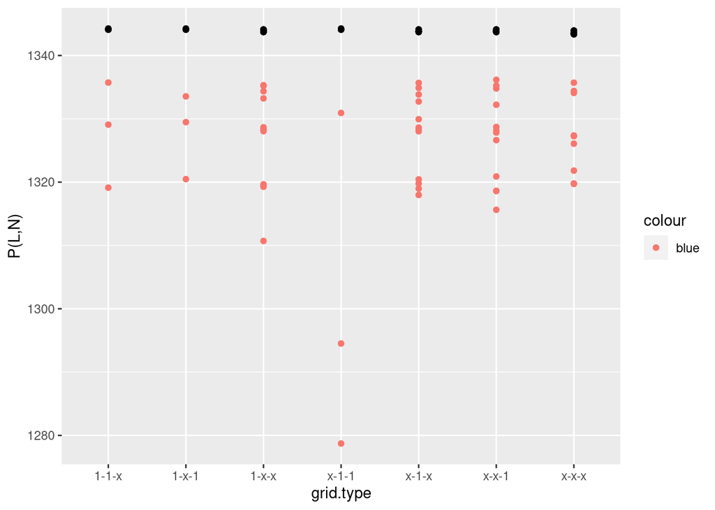